# Social Values Relate to Search for Information in Social Money Allocation Tasks

8/23/2021

##### Author of script: Marc Jekel [marc.jekel@uni-koeln.de]

##### OSF-link to study materials: https://osf.io/jpdzc/

# Load libraries

```r
rm(list = ls())

set.seed(1234)

library("ggplot2")
library("gridExtra")
library("grid")
library("readr")
library("ggExtra")
library("dplyr")
library("readxl")
library("tidyverse")
library("lme4")
library("lmerTest")
library("texreg")
library("ggpubr")
library("ggeffects")
library("osfr")
library("kableExtra")
loadData = 0

### connection to osf account marc_jekel_access_files

if(loadData == 1){

osf_auth("Kfzgya7YPgdUU0ImGYCcjJUiF60mqpawwSJFIVNRUSUbu0tfXBstBf4QyCRlV5OvBnQRkl")

osf_retrieve_node("z3nu4") %>%
  osf_ls_files(pattern="csv") %>%
  osf_download(conflicts = "overwrite")

}
```

# Study 1

## Read in data

```r
dats_s1 = read.csv2("data_study_1.csv")
```

## Tasks social value orientation

```r
tasks_svo =
  rbind(
    c(1.50,2.60,2.10,2.10),
    c(0,-3,-0.80,-2.90),
    c(3,0,2.90,-0.80),
    c(-2.90,.80,-2.6,1.5),
    c(-2.6,-1.5,-2.9,-.8),
    c(-.8,2.9,0,3),
    c(0,3,.8,2.9),
    c(-.8,-2.9,-1.5,-2.6),
    c(.8,-2.9,0,-3),
    c(2.1,-2.1,1.5,-2.6),
    c(2.9,-.8,2.6,-1.5),
    c(-2.1,-2.1,-2.6,-1.5),
    c(2.9,.8,3,0),
    c(-1.5,-2.6,-2.1,-2.1),
    c(-2.1,2.1,-1.5,2.6),
    c(.8,2.9,1.5,2.6),
    c(2.6,-1.5,2.1,-2.1),
    c(-1.5,2.6,-.8,2.9),
    c(1.5,-2.6,.8,-2.9),
    c(-3,0,-2.9,.8),
    c(2.6,1.5,2.9,.8),
    c(-2.6,1.5,-2.1,2.1),
    c(2.1,2.1,2.6,1.5),
    c(-2.9,-.8,-3,0)
  )

colnames(tasks_svo) = c("self_1","other_1","self_2","other_2")

SVO_choice = dats_s1[,13:36]
SVO_choice = matrix(unlist(SVO_choice),ncol=ncol(SVO_choice))
colnames(SVO_choice) = paste("SVO_",1:24,sep="")
```

## Angle social value orientation

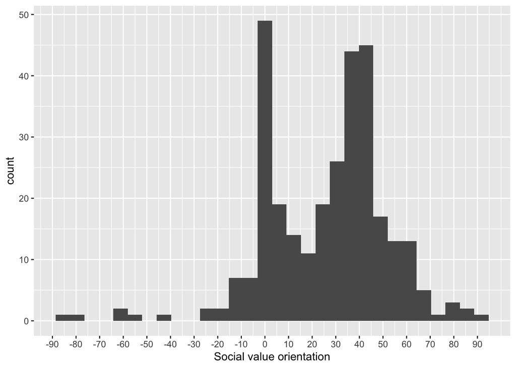

```r
SVO_part = numeric()

self_other_weights = numeric()

for(loopP in 1 : nrow(dats_s1)){

  tasks_svo_p = numeric()

  for(loopT in 1 : 24){

    if(SVO_choice[loopP,loopT] == 1){
      pickPart =   c(1,2)
    } else {
      pickPart = c(3,4)
    }

    tasks_svo_p = rbind(tasks_svo_p,
                        tasks_svo[loopT,pickPart])

  }

  self_other_mean= colSums(tasks_svo_p)

  self_other_weights = rbind(self_other_weights,self_other_mean)

  SVO_part = c(SVO_part,
               atan(self_other_mean[2]/self_other_mean[1])*180/pi)
}

SVO_part_pl = data.frame(SVO_part)

ggplot(SVO_part_pl, aes(x=SVO_part)) + geom_histogram() +
  labs(x = "Social value orientation")  +
  scale_x_continuous(breaks = seq(-90, 90, by=10))
```

```r
dats_s1 = dats_s1[is.na(SVO_part)==FALSE,]

self_other_weights = self_other_weights[is.na(SVO_part)==FALSE,]

SVO_part = SVO_part[is.na(SVO_part)==FALSE]

mean(SVO_part)
```

```
## [1] 26.26338
```

```r
sd(SVO_part)
```

```
## [1] 26.07976
```

## Demographics

### Number of participants

```r
n_part_s1 = nrow(dats_s1)
n_part_s1
```

```
## [1] 306
```

### Age

```r
age = dats_s1$v_132_alter
mean(age)
```

```
## [1] 30.78758
```

```r
sd(age)
```

```
## [1] 9.528076
```

### Gender

```r
# 1 = female, 2 = male, 3 = diverse

gender = dats_s1$v_133_Geschlecht
table(gender)
```

```
## gender
##   1   2   3
## 220  83   3
```

## Tasks with concealed information

```r
tasks = rbind(

  c(1.16,NA,.80, 1.50,NA,0),
  c(NA,1.94,1.14,2.33,NA,0.34),
  c(1.53,NA,2.17,NA,2.14,1.37),
  c(0.16,NA,3.25,0.38,NA,2.45),
  c(NA,4.44,4.06,NA,5.58,3.26),
  c(2.74,NA,5.13,3,NA,4.33),
  c(7.29,NA,5.93,NA,7.61,5.13),
  c(9.01,NA,7.28,NA,9.20,6.48),
  c(NA,0.18, 1.5,0.33,NA,0.8),
  c(NA,0.91,1.84,1.03,NA,1.14),
  c(2.35,NA,2.87,NA,4.23,2.17),
  c(1.19,NA,3.99,0.99,NA,3.25),
  c(2.23,NA,4.76,NA,1.35,3.60),
  c(NA,6.59,5.83,NA,7.09,5.13),
  c(NA,7.12,6.63,NA,7.68,5.93),
  c(NA,8.27,7.98,NA,8.76,7.28),
  c(0.86,NA,2.26,1.04,NA,1.19),
  c(1.30,NA,2.44,NA,2.80,1.84),
  c(3.40,NA,3.47,3.26,NA,2.87),
  c(1.86,NA,4.30,NA,1.25,3.40),
  c(3.51,NA,5.36,5.75,NA,4.76),
  c(NA,5.10,6.43,6.52,NA,5.83),
  c(4.60,NA,7.23,NA,6.81,6.63),
  c(7.79,NA,8.57,NA,8.79,7.98)
)

colnames(tasks) = c("self_1_1","self_1_2","other_1",
                    "self_2_1","self_2_2","other_2")

tasks_compl = rbind(

  c(1.16,1.74,.80, 1.50,1.50,0),
  c(1.30,1.94,1.14,2.33,1.01,0.34),
  c(1.53,2.74,2.17,2.23,2.14,1.37),
  c(0.16,5.19,3.25,0.38,5.07,2.45),
  c(1.48,4.44,4.06,0.54,5.58,3.26),
  c(2.74,4.49,5.13,3,3,4.33),
  c(7.29,0.34,5.93,0.16,7.61,5.13),
  c(9.01,0.27,7.28,0.28,9.20,6.48),
  c(2.42,0.18, 1.5,0.33,2.57,0.8),
  c(2.03,0.91,1.84,1.03,2.21,1.14),
  c(2.35,1.62,2.87,0.04,4.23,2.17),
  c(1.19,3.89,3.99,0.99,3.88,3.25),
  c(2.23,2.96,4.76,3.51,1.35,3.60),
  c(0.54,6.59,5.83,0.16,7.09,5.13),
  c(0.61,7.12,6.63,0.40,7.68,5.93),
  c(0.81,8.27,7.98,0.62,8.76,7.28),
  c(0.86,1.34,2.26,1.04,1.33,1.19),
  c(1.30,1.32,2.44,0.14,2.80,1.84),
  c(3.40,0.41,3.47,3.26,0.71,2.87),
  c(1.86,4.69,4.30,5.44,1.25,3.40),
  c(3.51,2.19,5.36,5.75,0.11,4.76),
  c(1.93,5.10,6.43,6.52,0.41,5.83),
  c(4.60,2.55,7.23,0.44,6.81,6.63),
  c(7.79,1.49,8.57,0.56,8.79,7.98)
)

colnames(tasks_compl) = c("self_1_1","self_1_2","other_1",
                          "self_2_1","self_2_2","other_2")

tasks_compl = data.frame(tasks_compl)

own_o1 = rowSums(tasks_compl[,1:2])
own_o2 = rowSums(tasks_compl[,3:4])

t.test(own_o1,own_o2,var.equal = T)
```

```
##
##  Two Sample t-test
##
## data:  own_o1 and own_o2
## t = -0.65196, df = 46, p-value = 0.5177
## alternative hypothesis: true difference in means is not equal to 0
## 95 percent confidence interval:
##  -2.042021  1.042854
## sample estimates:
## mean of x mean of y
##  5.578333  6.077917
```

```r
t.test(tasks_compl$other_1,tasks_compl$other_2,
       var.equal=T)
```

```
##
##  Two Sample t-test
##
## data:  tasks_compl$other_1 and tasks_compl$other_2
## t = 1.1388, df = 46, p-value = 0.2607
## alternative hypothesis: true difference in means is not equal to 0
## 95 percent confidence interval:
##  -0.5775537  2.0825537
## sample estimates:
## mean of x mean of y
##  4.384167  3.631667
```

## Attraction Search Effect

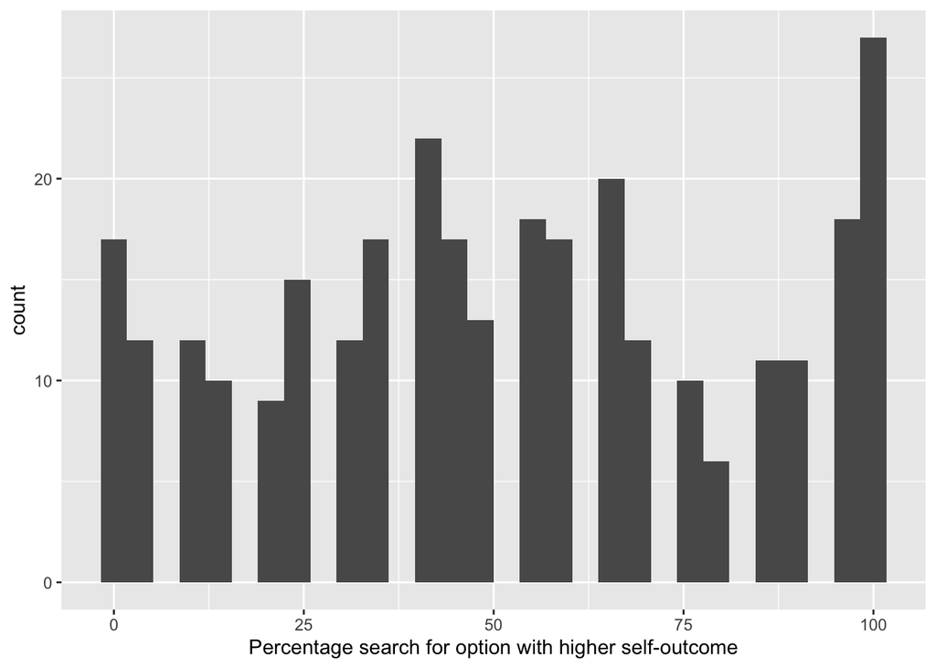

```r
ASE = dats_s1[,39:110]

ASE = ASE[,seq(1,72,3)]
ASE = matrix(unlist(ASE),ncol=ncol(ASE))
ASE = ifelse(ASE == 4,1,ASE)
ASE = ifelse(ASE == 3,2, ASE)

codeSocial = c(2,2,2,2,2,
               2,2,2,2,2,
               2,2,2,2,2,
               2,2,2,2,2,
               2,2,2,2)

ASE_pros = numeric()

for(loop in 1 : nrow(ASE)){

  ASE_pros = rbind(ASE_pros,ifelse(ASE[loop,] == codeSocial, 1, 0))
}

search_own_study_1 = ASE_pros

search_nondiag_study_1 = ASE_pros[,c(12,13,19,20)]

ASE_pros = ASE_pros[,-c(12,13,19,20)]

indiv_search = ASE_pros

table_perc_search_s1 = cbind(indiv_search,search_nondiag_study_1)
table_perc_search_s1 = round(100-colMeans(table_perc_search_s1) * 100)

ASE_pros_m = data.frame(100*rowMeans(ASE_pros))
colnames(ASE_pros_m) = "pros"

ASE_pros_m = unlist(ASE_pros_m)

ASE_pros_m_pl = data.frame(ASE_pros_m)

ggplot(ASE_pros_m_pl, aes(x=ASE_pros_m)) + geom_histogram() +
  labs(x = "Percentage search for option with higher self-outcome")
```

```r
mean(ASE_pros_m)
```

```
## [1] 51.79739
```

```r
sd(ASE_pros_m)
```

```
## [1] 30.5207
```

## Correlation between SVO and ASE

```r
res = data.frame("ASE_pros_m"=ASE_pros_m,"SVO_part"=SVO_part)

cor.test(res$SVO_part,res$ASE_pros_m,method = "spearman", alternative = "less")
```

```
##
##  Spearman's rank correlation rho
##
## data:  res$SVO_part and res$ASE_pros_m
## S = 7490930, p-value < 2.2e-16
## alternative hypothesis: true rho is less than 0
## sample estimates:
##        rho
## -0.5686547
```

```r
#### final plot ####

rect00 <- data.frame(x1=-90, x2=-67.5, y1=-Inf, y2=Inf)
rect0 <- data.frame (x1=-67.5, x2=-22.5, y1=-Inf, y2=Inf)
rect1 <- data.frame (x1=-22.5, x2=22.5, y1=-Inf, y2=Inf)
rect2 <- data.frame (x1=22.5, x2=67.5, y1=-Inf, y2=Inf)
rect3 <- data.frame (x1=67.5, x2=90, y1=-Inf, y2=Inf)

scatterP<- ggplot(data = res, aes(x = SVO_part, y = ASE_pros_m)) +
  geom_segment(aes(x=-90,xend=90,y=50,yend=50), color = "black", size=.5)+
  geom_segment(aes(x=-90,xend=-90,y=-3,yend=100), color = "black", size=.3,linetype="dotted")+
  geom_segment(aes(x=-45,xend=-45,y=-3,yend=100), color = "black", size=.3,linetype="dotted")+
  geom_segment(aes(x=0,xend=0,y=-3,yend=100), color = "black", size=.3,linetype="dotted")+
  geom_segment(aes(x=45,xend=45,y=-3,yend=100), color = "black", size=.3,linetype="dotted")+
  geom_segment(aes(x=90,xend=90,y=-3,yend=100), color = "black", size=.3,linetype="dotted")+
  geom_segment(aes(x=-90,xend=90,y=30,yend=30), color = "black", size=.3,linetype="dotted")+
  geom_segment(aes(x=-90,xend=90,y=70,yend=70), color = "black", size=.3,linetype="dotted")+
  geom_smooth(data = res, aes(x = SVO_part, y = ASE_pros_m),
              method = "lm", se = FALSE, lwd = 1, inherit.aes = FALSE,
              col ="grey")+
  geom_count() +
  scale_size_area(max_size=8) +
  labs(x = "Social value orientation",
       y = "Percentage of search for option with higher self payoff",
       color="Search bias")  +
  scale_x_continuous(limits=c(-90,90),breaks=c(-90,-67.5,-45,-22.5,0,22.5,45,67.5,90)) +
  scale_y_continuous(limits=c(-5,100),breaks=c(0,10,20,30,40,50,60,70,80,90,100)) +
  annotate(geom="text", x=-90, y=-5, label="sadistic",
           color="black")+
  annotate(geom="text", x=-45, y=-5, label="competitive",
           color="black")+
  annotate(geom="text", x=45, y=-5, label="cooperative",
           color="black")+
  annotate(geom="text", x=0, y=-5, label="individualistic",
           color="black")+
  annotate(geom="text", x=90, y=-5, label="altruistic",
           color="black")+
  geom_rect(data=rect00, mapping=aes(xmin =x1,
                                     xmax=x2,
                                     ymin=y1,
                                     ymax=y2),
            fill="white", alpha=0.3, inherit.aes = FALSE) +
  geom_rect(data=rect0, mapping=aes(xmin =x1,
                                    xmax=x2,
                                    ymin=y1,
                                    ymax=y2),
            fill="grey", alpha=0.3, inherit.aes = FALSE) +
  geom_rect(data=rect1, mapping=aes(xmin =x1,
                                    xmax=x2,
                                    ymin=y1,
                                    ymax=y2),
            fill="white", alpha=0.3, inherit.aes = FALSE) +
  geom_rect(data=rect2, mapping=aes(xmin =x1,
                                    xmax=x2,
                                    ymin=y1,
                                    ymax=y2),
            fill="grey", alpha=0.3, inherit.aes = FALSE)+
  geom_rect(data=rect3, mapping=aes(xmin =x1,
                                    xmax=x2,
                                    ymin=y1,
                                    ymax=y2),
            fill="white", alpha=0.3, inherit.aes = FALSE)+
  scale_color_manual(values = c("red", "chartreuse4")) +
  theme_bw()

pdf("study_1_main.pdf",pagecentre=T, width=10,height=7 ,paper = "special")

ggMarginal(scatterP, type="densigram")
dev.off()
```

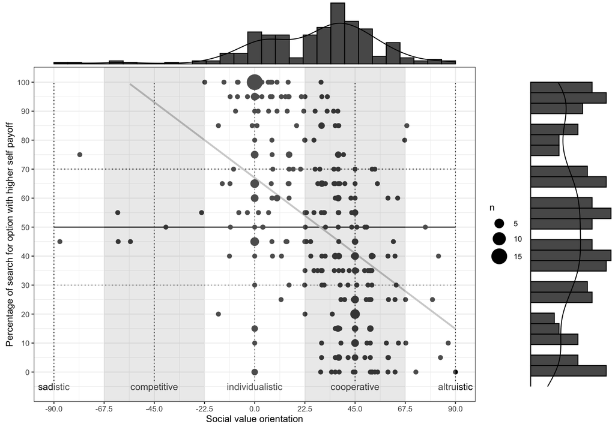

```r
ggMarginal(scatterP, type="densigram")
```

## Multilevel regression models

```r
indiv_search = c(indiv_search)

tasks = data.frame(tasks)

SVO_tasks_2_single =
  data.frame(rowSums(cbind(tasks$self_1_1, tasks$self_1_2),na.rm=T),
             tasks$other_1,
             rowSums(cbind(tasks$self_2_1, tasks$self_2_2),na.rm=T),
             tasks$other_2)

colnames(SVO_tasks_2_single) = c("S_1_1","O_1","S_2_1","O_2")

self_ratio =   (SVO_tasks_2_single$S_2_1 / SVO_tasks_2_single$S_1_1)
other_ratio =  (SVO_tasks_2_single$O_1 / SVO_tasks_2_single$O_2)

other_ratio[1] = NA

incl = rep(1,24)
incl[c(12,13,19,20)] = 0

self_ratio = self_ratio[incl==1]
other_ratio = other_ratio[incl==1]

dats_analy = data.frame("id"=rep(1:n_part_s1,20),
                        "search"=indiv_search,
                        "SVO"=rep(SVO_part,20),
                        "Own" = rep(self_ratio,each=n_part_s1),
                        "Other" = rep(other_ratio,each=n_part_s1)
)


mean_svo = mean(dats_analy$SVO)

mean_self = mean(dats_analy$Own)
sd_self = sd(dats_analy$Own)

mean_other = mean(dats_analy$Other,na.rm=T)
sd_other = sd(dats_analy$Other,na.rm=T)


dats_analy$SVO = dats_analy$SVO - mean(dats_analy$SVO)
dats_analy$Own = dats_analy$Own - mean(dats_analy$Own,na.rm=T)
dats_analy$Other= dats_analy$Other - mean(dats_analy$Other,na.rm=T)

mod = list()
mod_expl = list()

mod[1] = glmer(search ~ SVO  + (1|id),data=dats_analy,
               family = "binomial")
mod_expl[1] = glmer(search ~ SVO* Own +SVO*Other+(1|id),data=dats_analy,
                    family = "binomial")
names_mod = c("Intercept","SVO")

htmlreg(mod, custom.coef.names=names_mod,digits=3)
```

Statistical models

|  | Model 1 |
| --- | --- |
| Intercept | 0.144 |
|  | (0.097) |
| SVO | -0.036*** |
|  | (0.004) |
| AIC | 6667.074 |
| BIC | 6687.232 |
| Log Likelihood | -3330.537 |
| Num. obs. | 6120 |
| Num. groups: id | 306 |
| Var: id (Intercept) | 2.482 |

p < 0.001; p < 0.01; p < 0.05

### Prepare plot model predictions

```r
mod = glmer(search ~ SVO +
              (1|id),data=dats_analy,
            family = "binomial")

pred = ggpredict(mod,terms=c("SVO [all]"))

pred$x = pred$x + mean_svo

pl_1_s_1 = ggplot(pred, aes(x, predicted)) +
  geom_line()+
  geom_ribbon(aes(ymin=conf.low, ymax=conf.high), alpha=0.15) +
  scale_y_continuous(limits=c(0,1),
                     breaks=c(0,.1,.2,.3,.4,.5,.6,.7,.8,.9,1))+
  scale_x_continuous(limits=c(-90,91),breaks=c(-90,-67.5,-45,-22.5,0,22.5,45,67.5,90)) +
  geom_segment(aes(x=-90,xend=90,y=.5,yend=.5), color = "grey")+
  geom_segment(aes(x=-90,xend=-90,y=.05,yend=1), color = "grey")+
  geom_segment(aes(x=-45,xend=-45,y=.05,yend=1), color = "grey")+
  geom_segment(aes(x=0,xend=0,y=.05,yend=1), color = "grey")+
  geom_segment(aes(x=45,xend=45,y=.05,yend=1), color = "grey")+
  geom_segment(aes(x=90,xend=90,y=.05,yend=1), color = "grey")+
  annotate(geom="text", x=-90, y=.01, label="sadistic",
           color="black")+
  annotate(geom="text", x=-45, y=.01, label="competitive",
           color="black")+
  annotate(geom="text", x=45, y=.01, label="cooperative",
           color="black")+
  annotate(geom="text", x=0, y=.01, label="individualistic",
           color="black")+
  annotate(geom="text", x=90, y=.01, label="altruistic",
           color="black")+
  ylab("Likelihood of search for option with higher own payoff") +
  xlab("Social value orientation")

##

dats_analy$Own = dats_analy$Own - mean_self
dats_analy$Other = dats_analy$Other - mean_other

mod = glmer(search ~   SVO*Own + SVO*Other +
              (1|id),data=dats_analy,
            family = "binomial")

pred = ggpredict(mod,terms=c("SVO [all]","Own"))

pred$x = pred$x + mean_svo

levels(pred$group) = c(round(mean_self-sd_self,2),round(mean_self,2),round(mean_self+sd_self,2))

pl_2 = ggplot(pred, aes(x, predicted)) +
  geom_line(aes(linetype=group)) +
  scale_y_continuous(limits=c(0,1),
                     breaks=c(0,.1,.2,.3,.4,.5,.6,.7,.8,.9,1))+
  scale_x_continuous(limits=c(-90,90),breaks=c(-90,-67.5,-45,-22.5,0,22.5,45,67.5,90)) +
  geom_segment(aes(x=-90,xend=90,y=.5,yend=.5), color = "grey")+
  geom_segment(aes(x=-90,xend=-90,y=.05,yend=1), color = "grey")+
  geom_segment(aes(x=-45,xend=-45,y=.05,yend=1), color = "grey")+
  geom_segment(aes(x=0,xend=0,y=.05,yend=1), color = "grey")+
  geom_segment(aes(x=45,xend=45,y=.05,yend=1), color = "grey")+
  geom_segment(aes(x=90,xend=90,y=.05,yend=1), color = "grey")+
  annotate(geom="text", x=-90, y=.01, label="sadistic",
           color="black")+
  annotate(geom="text", x=-45, y=.01, label="competitive",
           color="black")+
  annotate(geom="text", x=45, y=.01, label="cooperative",
           color="black")+
  annotate(geom="text", x=0, y=.01, label="individualistic",
           color="black")+
  annotate(geom="text", x=90, y=.01, label="altruistic",
           color="black") +
  guides(linetype=guide_legend("Ratio own payoff")) +
  ylab("Likelihood of search for option with higher own payoff") +
  xlab("Social value orientation")+ theme(legend.position="bottom")

##

pred = ggpredict(mod,terms=c("SVO [all]","Other"))

pred$x = pred$x + mean_svo
levels(pred$group) = c(round(mean_other-sd_other,2),round(mean_other,2),round(mean_other+sd_other,2))

pl_3 = ggplot(pred, aes(x, predicted)) +
  geom_line(aes(linetype=group)) +
  scale_y_continuous(limits=c(0,1),
                     breaks=c(0,.1,.2,.3,.4,.5,.6,.7,.8,.9,1))+
  scale_x_continuous(limits=c(-90,90),breaks=c(-90,-67.5,-45,-22.5,0,22.5,45,67.5,90)) +
  geom_segment(aes(x=-90,xend=90,y=.5,yend=.5), color = "grey")+
  geom_segment(aes(x=-90,xend=-90,y=.05,yend=1), color = "grey")+
  geom_segment(aes(x=-45,xend=-45,y=.05,yend=1), color = "grey")+
  geom_segment(aes(x=0,xend=0,y=.05,yend=1), color = "grey")+
  geom_segment(aes(x=45,xend=45,y=.05,yend=1), color = "grey")+
  geom_segment(aes(x=90,xend=90,y=.05,yend=1), color = "grey")+
  annotate(geom="text", x=-90, y=.01, label="sadistic",
           color="black")+
  annotate(geom="text", x=-45, y=.01, label="competitive",
           color="black")+
  annotate(geom="text", x=45, y=.01, label="cooperative",
           color="black")+
  annotate(geom="text", x=0, y=.01, label="individualistic",
           color="black")+
  annotate(geom="text", x=90, y=.01, label="altruistic",
           color="black") +
  guides(linetype=guide_legend("Ratio other's payoff")) +
  ylab("Likelihood of search for option with higher own payoff") +
  xlab("Social value orientation")+ theme(legend.position="bottom")


##

pred_val = seq(1-mean_self,3-mean_self,.1)
pred_string = paste("Own [",paste(pred_val,collapse=","),"]",collapse="")

pred_1 = ggpredict(mod,terms=pred_string)

pred_1$x = pred_1$x + mean_self

pred_val = seq(1-mean_other,3-mean_other,.1)
pred_string = paste("Other [",paste(pred_val,collapse=","),"]",collapse="")

pred_2 = ggpredict(mod,terms=pred_string)
pred_2$x = pred_2$x + mean_other

pl_data = data.frame(c(pred_1$x,pred_2$x),c(pred_1$predicted,pred_2$predicted),
                     as.factor(c(rep("Own",length(pred_1$x)),rep("Other",length(pred_2$x))))
)

names(pl_data) = c("x","predicted","group")

pl_4 = ggplot(pl_data, aes(x, predicted)) +
  geom_line(aes(linetype=group)) +
  scale_y_continuous(limits=c(0,1),
                     breaks=c(0,.1,.2,.3,.4,.5,.6,.7,.8,.9,1))+
  scale_x_continuous(limits=c(1,3.1))+
  geom_segment(aes(x=1,xend=3,y=.5,yend=.5), color = "grey")+
  guides(linetype=guide_legend("Type of payoff")) +
  ylab("Likelihood of search for option with higher own payoff") +
  xlab("Ratio payoff") + theme(legend.position="bottom") +
  scale_linetype(labels = c("Other's", "Own"))


pl_main_s1 =pl_4
pl_self_s1 = pl_2
pl_other_s1 = pl_3
```

# Study 2

## Read in data

```r
dats_s2_1 =  read_csv("data_study_2_session_1.csv")
```

```
## * `` -> ...1
```

```r
dats_s2_2 = read_csv("data_study_2_session_2.csv")
```

```
## * `` -> ...1
```

## Demographics

### Number of participants

```r
n_part_s2 = nrow(dats_s2_1)
n_part_s2
```

```
## [1] 188
```

### Age

```r
dats_s2_1$Age = ifelse(dats_s2_1$Age == 999, NA, dats_s2_1$Age)

age = dats_s2_1$Age
mean(age, na.rm=T)
```

```
## [1] 28.14595
```

```r
sd(age, na.rm=T)
```

```
## [1] 8.949453
```

### Gender

```r
dats_s2_1$Sex = ifelse(dats_s2_1$Sex == "männlich", "male",dats_s2_1$Sex)
dats_s2_1$Sex = ifelse(dats_s2_1$Sex == "weiblich", "female",dats_s2_1$Sex)
dats_s2_1$Sex = ifelse(dats_s2_1$Sex == "divers", "diverse",dats_s2_1$Sex)
dats_s2_1$Sex = ifelse(dats_s2_1$Sex == "möchte ich nicht angeben", "no answer",dats_s2_1$Sex)

gender = dats_s2_1$Sex
table(gender)
```

```
## gender
##   diverse    female      male no answer
##         3       112        70         3
```

### Time difference in days between sessions

```r
start_date =  as.numeric(str_sub(dats_s2_1$StartDate,9,10))
end_date = as.numeric( str_sub(dats_s2_2$EndDate,9,10))
end_date = ifelse(end_date<16,31+end_date,end_date)

days = end_date - start_date

table(days)
```

```
## days
##   5   7   8   9  10  11  12
##   2 124  40  10   8   1   3
```

## Session 1

```r
order_pres = dats_s2_1 %>% select(
  contains("Trial"))

order_pres = matrix(as.numeric(unlist(order_pres)),
                    ncol = ncol(order_pres))

order_options = dats_s2_1 %>% select(
  contains("Pres"))

order_options = order_options[,2:ncol(order_options)]

order_options = matrix(as.numeric(unlist(order_options)),
                       ncol = ncol(order_options))

choice = dats_s2_1 %>% select(
  contains("SVO_choice"))
choice = ifelse(choice == "Linke Option",1,2)

for(loop_part in 1 : nrow(dats_s2_1)){
  for(loop_trial in 1 : 24){

    act_part = order_options[loop_part,order_pres[loop_part,]]

    if(act_part[loop_trial] == 0){

      choice[loop_part,loop_trial] =
        ifelse(choice[loop_part,loop_trial] == 2,1,2)
    }
  }
}

SVO_choice = choice
```

### Money first session

```r
random_SVO_1 = numeric()

for(loop_part in 1 : nrow(SVO_choice)){

  pick_task = sample(1:24,1)

  act_choice_part = choice[loop_part,pick_task]

  ind_ch = c(1,2) + (act_choice_part-1) * 2

  random_SVO_1 = rbind(random_SVO_1,
                       unlist(tasks_svo[pick_task,ind_ch]))

}

random_SVO_1 = data.frame(random_SVO_1)
colnames(random_SVO_1) = c("Own","Other")

others = sample(1:nrow(dats_s2_1),nrow(dats_s2_1)/2)

others = cbind(others,sample((1:nrow(dats_s2_1))[-others]))

others = rbind(others,others[,2:1])
others = others[order(others[,1]),]
colnames(others) = c("key","target")
others = data.frame(others)

total_money_1 = numeric()

for(loop_part in 1 : nrow(dats_s2_1)){

  total_money_1 = c(total_money_1,

                    random_SVO_1$Own[loop_part] +
                      random_SVO_1$Other[others$target[loop_part]])

}
```

### Angle social value orientation

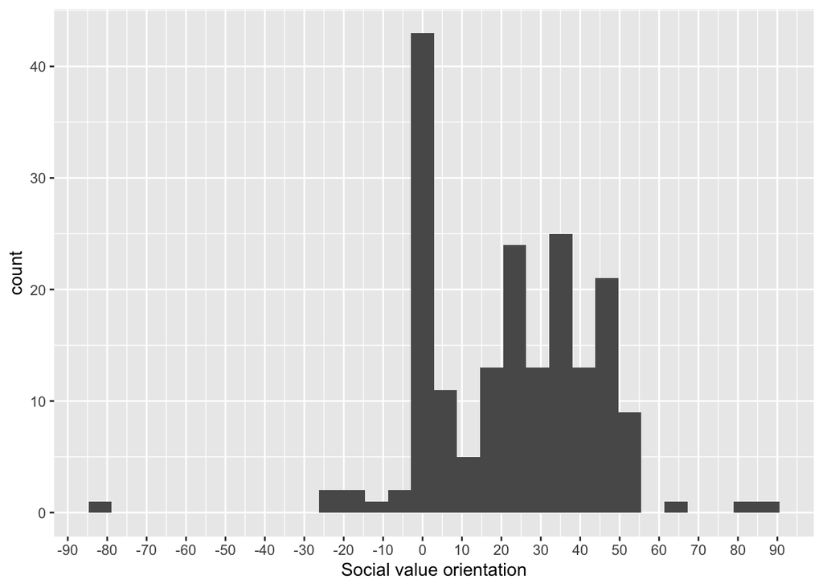

```r
SVO_part = numeric()
SVO_tasks_1 = data.frame(tasks_svo)
colnames(SVO_tasks_1) = c("S_1",    "O_1",  "S_2",  "O_2")

SVO_tasks_1 = matrix(unlist(SVO_tasks_1),ncol = ncol(SVO_tasks_1))

for(loopP in 1 : nrow(dats_s2_1)){

  tasks_svo_p = numeric()

  for(loopT in 1 : 24){

    if(SVO_choice[loopP,loopT] == 1){
      pickPart =   c(1,2)
    } else {
      pickPart = c(3,4)
    }

    tasks_svo_p = rbind(tasks_svo_p,
                        SVO_tasks_1[loopT,pickPart])

  }

  self_other_mean= colSums(tasks_svo_p)

  SVO_part = c(SVO_part,
               atan(self_other_mean[2]/self_other_mean[1])*180/pi)
}


SVO_part_pl = data.frame(SVO_part)

ggplot(SVO_part_pl, aes(x=SVO_part)) + geom_histogram() +
  labs(x = "Social value orientation") +
  scale_x_continuous(breaks = seq(-90, 90, by=10))
```

```r
mean(SVO_part)
```

```
## [1] 22.30188
```

```r
sd(SVO_part)
```

```
## [1] 21.508
```

## Session 2

### Tasks with concealed information

```r
SVO_tasks_2 = rbind(
  c(1.16,1.74,0.8,1.5,1.5,0),
  c(1.94,1.3,1.14,2.33,1.01,0.34),
  c(1.53,2.74,2.17,2.14,2.23,1.37),
  c(0.08,2.6,1.63,0.19,2.54,1.23),
  c(2.22,0.74,2.03,2.79,0.27,1.63),
  c(1.37,2.25,2.57,1.5,2.17,2.17),
  c(3.65,0.17,2.97,3.81,0.08,2.57),
  c(4.51,0.14,3.64,4.6,0.14,3.24),
  c(0.18,2.42,1.5,0.33,2.57,0.8),
  c(0.91,2.03,1.84,1.03,2.21,1.14),
  c(2.35,1.62,2.87,4.23,0.04,2.17),
  c(1.19,3.89,3.99,0.99,3.88,3.25),
  c(2.23,2.96,4.76,1.35,3.51,3.6),
  c(3.3,0.27,2.92,3.55,0.08,2.57),
  c(3.56,0.31,3.32,3.84,0.2,2.97),
  c(2.07,0.2,2,2.19,0.16,1.82),
  c(0.86,1.34,2.26,1.04,1.33,1.19),
  c(1.3,1.32,2.44,2.8,0.14,1.84),
  c(3.4,0.41,3.47,3.26,0.71,2.87),
  c(0.93,2.35,2.15,0.63,2.72,1.7),
  c(3.51,2.19,5.36,5.75,0.11,4.76),
  c(2.55,0.97,3.22,3.26,0.21,2.92),
  c(2.3,1.28,3.62,3.41,0.22,3.32),
  c(3.9,0.75,4.29,4.4,0.28,3.99)
)


SVO_tasks_2 = data.frame(SVO_tasks_2)

colnames(SVO_tasks_2) = c("S_1_1",  "S_1_2" ,"O_1", "S_2_1" ,"S_2_2",   "O_2")

tasks_svo_table_3 = SVO_tasks_2
```

### Total money

```r
SVO_tasks_2
```

```
##    S_1_1 S_1_2  O_1 S_2_1 S_2_2  O_2
## 1   1.16  1.74 0.80  1.50  1.50 0.00
## 2   1.94  1.30 1.14  2.33  1.01 0.34
## 3   1.53  2.74 2.17  2.14  2.23 1.37
## 4   0.08  2.60 1.63  0.19  2.54 1.23
## 5   2.22  0.74 2.03  2.79  0.27 1.63
## 6   1.37  2.25 2.57  1.50  2.17 2.17
## 7   3.65  0.17 2.97  3.81  0.08 2.57
## 8   4.51  0.14 3.64  4.60  0.14 3.24
## 9   0.18  2.42 1.50  0.33  2.57 0.80
## 10  0.91  2.03 1.84  1.03  2.21 1.14
## 11  2.35  1.62 2.87  4.23  0.04 2.17
## 12  1.19  3.89 3.99  0.99  3.88 3.25
## 13  2.23  2.96 4.76  1.35  3.51 3.60
## 14  3.30  0.27 2.92  3.55  0.08 2.57
## 15  3.56  0.31 3.32  3.84  0.20 2.97
## 16  2.07  0.20 2.00  2.19  0.16 1.82
## 17  0.86  1.34 2.26  1.04  1.33 1.19
## 18  1.30  1.32 2.44  2.80  0.14 1.84
## 19  3.40  0.41 3.47  3.26  0.71 2.87
## 20  0.93  2.35 2.15  0.63  2.72 1.70
## 21  3.51  2.19 5.36  5.75  0.11 4.76
## 22  2.55  0.97 3.22  3.26  0.21 2.92
## 23  2.30  1.28 3.62  3.41  0.22 3.32
## 24  3.90  0.75 4.29  4.40  0.28 3.99
```

```r
SVO_tasks_2_single = SVO_tasks_2

SVO_tasks_2 = data.frame(

  SVO_tasks_2$S_1_1 + SVO_tasks_2$S_1_2,SVO_tasks_2$O_1,
  SVO_tasks_2$S_2_1+SVO_tasks_2$S_2_2,SVO_tasks_2$O_2)

colnames(SVO_tasks_2) = c("S_1","O_1","S_2","O_2")

t.test(SVO_tasks_2$S_1,SVO_tasks_2$S_2,var.equal=T)
```

```
##
##  Two Sample t-test
##
## data:  SVO_tasks_2$S_1 and SVO_tasks_2$S_2
## t = -0.3568, df = 46, p-value = 0.7229
## alternative hypothesis: true difference in means is not equal to 0
## 95 percent confidence interval:
##  -0.6198714  0.4332047
## sample estimates:
## mean of x mean of y
##  3.624583  3.717917
```

```r
t.test(SVO_tasks_2$O_1,SVO_tasks_2$O_2,var.equal = T)
```

```
##
##  Two Sample t-test
##
## data:  SVO_tasks_2$O_1 and SVO_tasks_2$O_2
## t = 1.6856, df = 46, p-value = 0.09864
## alternative hypothesis: true difference in means is not equal to 0
## 95 percent confidence interval:
##  -0.1092082  1.2342082
## sample estimates:
## mean of x mean of y
##    2.7900    2.2275
```

```r
###

random_SVO_2 = numeric()

for(loop_part in 1 : nrow(dats_s2_2)){

  pick_task = sample(1:24,1)

  act_choice_part = choice[loop_part,pick_task]

  ind_ch = c(1,2) + (act_choice_part-1) * 2

  random_SVO_2 = rbind(random_SVO_2,
                       unlist(SVO_tasks_2[pick_task,ind_ch]))

}

random_SVO_2 = data.frame(random_SVO_2)
colnames(random_SVO_2) = c("Own","Other")

others = sample(1:nrow(dats_s2_2),nrow(dats_s2_2)/2)

others = cbind(others,sample((1:nrow(dats_s2_2))[-others]))

others = rbind(others,others[,2:1])
others = others[order(others[,1]),]
colnames(others) = c("key","target")
others = data.frame(others)

total_money_2 = numeric()

for(loop_part in 1 : nrow(dats_s2_2)){

  total_money_2 = c(total_money_2,

                    random_SVO_2$Own[loop_part] +
                      random_SVO_2$Other[others$target[loop_part]])

}

total_money = 3 + total_money_1 + total_money_2
total_money = ifelse(total_money<3,3,total_money)

mean(total_money)
```

```
## [1] 9.694096
```

```r
sd(total_money)
```

```
## [1] 3.330878
```

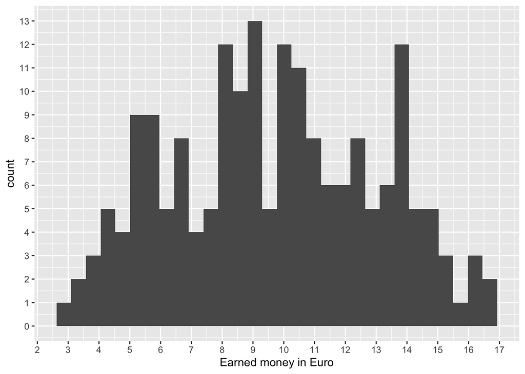

```r
total_money = data.frame(total_money)

ggplot(total_money, aes(x=total_money)) + geom_histogram() +
  labs(x = "Earned money in Euro") +
  scale_y_continuous(breaks = seq(0, 20, by=1)) +
  scale_x_continuous(breaks = seq(0, 20, by=1))
```

### Attraction Search Effect

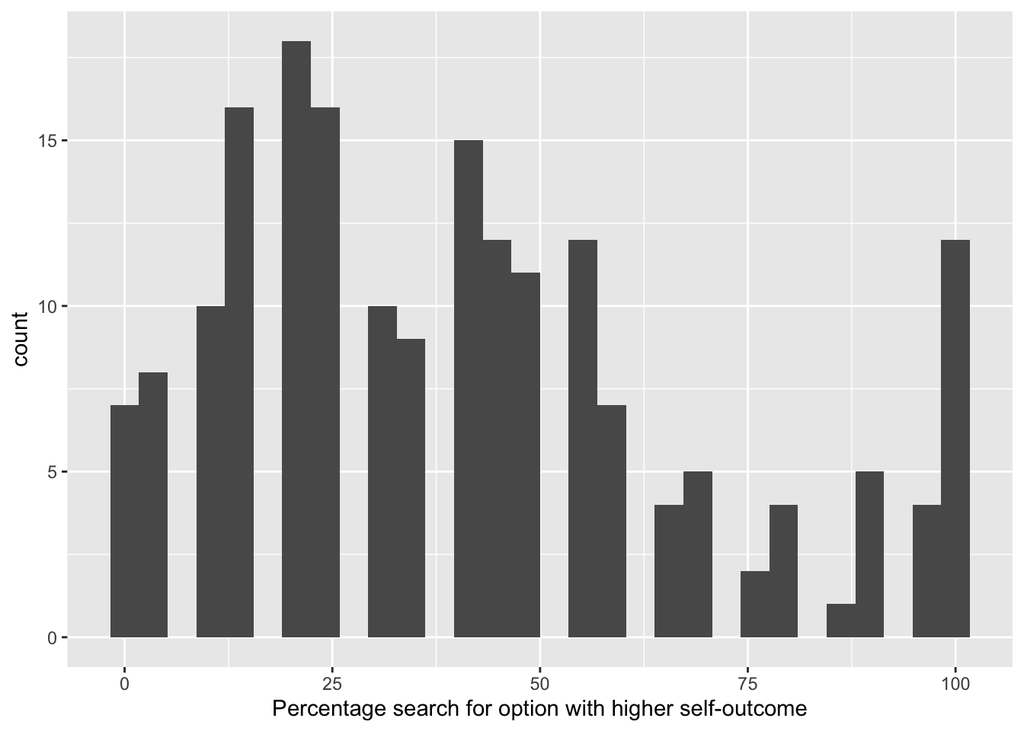

```r
order_pres = dats_s2_2 %>% select(
  contains("Trial"))
order_pres = matrix(as.numeric(unlist(order_pres)),
                    ncol = ncol(order_pres))

order_options = dats_s2_2 %>% select(
  contains("Pres"))

order_options = order_options[,1:24]

order_options = matrix(as.numeric(unlist(order_options)),
                       ncol = ncol(order_options))

choice = dats_s2_2 %>% select(
  contains("SVO_choice"))
choice = ifelse(choice == "Linke Option",1,2)

search = dats_s2_2  %>% select(
  contains("search") & !contains("Time") &  !contains("example")
)

search = ifelse(search == "Verdeckter Betrag der linken Option",1,2)

for(loop_part in 1 : nrow(dats_s2_2)){
  for(loop_trial in 1 :24){

    act_part = order_options[loop_part,][order_pres[loop_part,]]

    if(act_part[loop_trial] == 0){

      choice[loop_part,loop_trial] =
        ifelse(choice[loop_part,loop_trial] == 2,1,2)

      search[loop_part,loop_trial] =
        ifelse(search[loop_part,loop_trial] == 2,1,2)

    }
  }
}

incl = (cbind(SVO_tasks_2_single$S_1_1 > SVO_tasks_2_single$S_2_1,
              SVO_tasks_2_single$O_1 > SVO_tasks_2_single$O_2))

incl = ifelse(rowSums(incl)==1,1,0)

search_nondiag_study_2 = ifelse(search == 2,1,0)
search_nondiag_study_2 = search_nondiag_study_2[,incl==0]

search = search[,incl == 1]
indiv_search = ifelse(search == 2,1,0)

score_indiv_search = rowSums(indiv_search)

score_indiv_search_pl = data.frame(100*score_indiv_search/20)

ggplot(score_indiv_search_pl, aes(x=X100...score_indiv_search.20)) + geom_histogram() +
  labs(x = "Percentage search for option with higher self-outcome")
```

```r
mean(unlist(score_indiv_search_pl))
```

```
## [1] 41.06383
```

```r
sd(unlist(score_indiv_search_pl))
```

```
## [1] 27.78712
```

```r
table_perc_search_s2 = cbind(indiv_search,search_nondiag_study_2)
table_perc_search_s2 = round(100-colMeans(table_perc_search_s2) * 100)
```

## Correlation between ASE and SVO

```r
cor.test(SVO_part,score_indiv_search,method="spearman",alternative="less")
```

```
##
##  Spearman's rank correlation rho
##
## data:  SVO_part and score_indiv_search
## S = 1382193, p-value = 0.0002981
## alternative hypothesis: true rho is less than 0
## sample estimates:
##        rho
## -0.2481268
```

```r
cor.test(SVO_part,score_indiv_search)
```

```
##
##  Pearson's product-moment correlation
##
## data:  SVO_part and score_indiv_search
## t = -4.0281, df = 186, p-value = 8.184e-05
## alternative hypothesis: true correlation is not equal to 0
## 95 percent confidence interval:
##  -0.4097599 -0.1460714
## sample estimates:
##        cor
## -0.2832603
```

### Correlation between SVO ring measure and SVO slider from Decision Lab Cologne

```r
SVO_dlc = read.csv("svo_dlc.csv")

date_slider = SVO_dlc$Date
date_slider = str_sub(date_slider, 1, 10)

year =  as.numeric(str_sub(date_slider, 1, 4))
month = as.numeric( str_sub(date_slider, 6,7))

date_slider = data.frame(year,month)
date_slider = date_slider[order(date_slider$year,date_slider$month),]

date_slider = table(date_slider$year,date_slider$month)
date_slider =cbind(date_slider,rowSums(date_slider ),rowSums(date_slider )/sum(date_slider))

sum((7 - c(1:8,10:12)) * date_slider[3,1:11] +
(7 + c(12:10,8:1)) * date_slider[2,1:11] +
(7 +12 + c(12:10,8:1)) * date_slider[3,1:11]) /n_part_s2
```

```
## [1] 10.23936
```

```r
cor.test(SVO_dlc$SVSangle,SVO_part)
```

```
##
##  Pearson's product-moment correlation
##
## data:  SVO_dlc$SVSangle and SVO_part
## t = 5.4608, df = 186, p-value = 1.504e-07
## alternative hypothesis: true correlation is not equal to 0
## 95 percent confidence interval:
##  0.2414473 0.4888205
## sample estimates:
##       cor
## 0.3717135
```

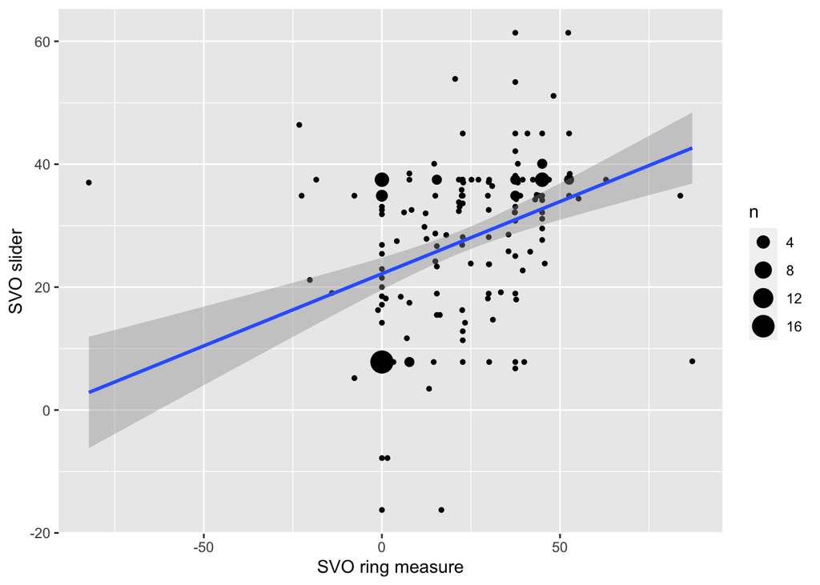

```r
SVOscales = data.frame(SVO_dlc$SVSangle,SVO_part)

names(SVOscales) = c("SVO_slider","SVO_ring")

ggplot(SVOscales,aes(x=SVO_ring,y=SVO_slider)) +  geom_count() +
  labs(x = "SVO ring measure",
       y = "SVO slider")  +
  geom_smooth(method = "lm")
```

### Correlation based on SVO slider from Decision Lab Cologne

```r
cor.test(SVO_dlc$SVSangle,score_indiv_search,method="spearman",alternative="less")
```

```
##
##  Spearman's rank correlation rho
##
## data:  SVO_dlc$SVSangle and score_indiv_search
## S = 1350450, p-value = 0.001239
## alternative hypothesis: true rho is less than 0
## sample estimates:
##        rho
## -0.2194629
```

```r
cor.test(SVO_dlc$SVSangle,score_indiv_search,method="pearson",alternative="less")
```

```
##
##  Pearson's product-moment correlation
##
## data:  SVO_dlc$SVSangle and score_indiv_search
## t = -3.2678, df = 186, p-value = 0.0006454
## alternative hypothesis: true correlation is less than 0
## 95 percent confidence interval:
##  -1.0000000 -0.1159169
## sample estimates:
##        cor
## -0.2330123
```

### Correlation based on average between SVO ring measure form session 1 and SVO slider from Decision Lab Cologne

```r
SVO_average = ((SVO_part + SVO_dlc$SVSangle)/2)

cor.test(SVO_average,score_indiv_search,method="spearman",alternative="less")
```

```
##
##  Spearman's rank correlation rho
##
## data:  SVO_average and score_indiv_search
## S = 1401967, p-value = 0.0001124
## alternative hypothesis: true rho is less than 0
## sample estimates:
##        rho
## -0.2659828
```

```r
cor.test(SVO_average,score_indiv_search,method="pearson",alternative="less")
```

```
##
##  Pearson's product-moment correlation
##
## data:  SVO_average and score_indiv_search
## t = -4.5247, df = 186, p-value = 5.381e-06
## alternative hypothesis: true correlation is less than 0
## 95 percent confidence interval:
##  -1.0000000 -0.2022084
## sample estimates:
##        cor
## -0.3148915
```

## Condition preference assessment

```r
# 1 = with preference assessment befor search, 0 = without

cond = dats_s2_2$preference
cond = as.numeric(cond)

table(cond)
```

```
## cond
##  0  1
## 90 98
```

### Correlation per condition

```r
cor.test(SVO_part[cond==1],score_indiv_search[cond==1],method="spearman",alternative="less")
```

```
##
##  Spearman's rank correlation rho
##
## data:  SVO_part[cond == 1] and score_indiv_search[cond == 1]
## S = 201966, p-value = 0.002039
## alternative hypothesis: true rho is less than 0
## sample estimates:
##        rho
## -0.2876485
```

```r
cor.test(SVO_part[cond==0],score_indiv_search[cond==0],method="spearman",alternative="less")
```

```
##
##  Spearman's rank correlation rho
##
## data:  SVO_part[cond == 0] and score_indiv_search[cond == 0]
## S = 147284, p-value = 0.02224
## alternative hypothesis: true rho is less than 0
## sample estimates:
##        rho
## -0.2123648
```

#### Bootstrapped confidence intervals for difference in correlations

```r
diff_rho = rep(NA, 10000)

for(loop_bootstrap in 1 : 10000){

  SVO_part_bootstrap_group_with_assessment = SVO_part[cond==1]
  SVO_part_bootstrap_group_without_assessment = SVO_part[cond==0]
  ASE_bootstrap_group_with_assessment = score_indiv_search[cond==1]
  ASE_bootstrap_group_without_assessment = score_indiv_search[cond==0]

  pick_with_assessment = sample(1:length(SVO_part_bootstrap_group_with_assessment),rep=T)
  pick_without_assessment = sample(1:length(SVO_part_bootstrap_group_without_assessment),rep=T)

  diff_rho[loop_bootstrap] =
    cor(SVO_part_bootstrap_group_with_assessment[pick_with_assessment],
        ASE_bootstrap_group_with_assessment[pick_with_assessment],method="spearman")-
    cor(SVO_part_bootstrap_group_without_assessment[pick_without_assessment] ,
        ASE_bootstrap_group_without_assessment[pick_without_assessment],method="spearman")


}

diff_rho = sort(diff_rho)

diff_rho[250]
```

```
## [1] -0.3611732
```

```r
diff_rho[9750]
```

```
## [1] 0.2102743
```

## Plot Correlation between SVO and ASE

```r
ASE_pros_m = c(100*score_indiv_search/20)
res_fin = data.frame("ASE_pros_m"=ASE_pros_m,"SVO_part"=SVO_part,
                     "cond"=cond)

res_fin$cond = as.factor(res_fin$cond)
levels(res_fin$cond) = c("No","Yes")

rect00 <- data.frame(x1=-90, x2=-67.5, y1=-Inf, y2=Inf)
rect0 <- data.frame (x1=-67.5, x2=-22.5, y1=-Inf, y2=Inf)
rect1 <- data.frame (x1=-22.5, x2=22.5, y1=-Inf, y2=Inf)
rect2 <- data.frame (x1=22.5, x2=67.5, y1=-Inf, y2=Inf)
rect3 <- data.frame (x1=67.5, x2=90, y1=-Inf, y2=Inf)

scatterP<- ggplot(data = res_fin, aes(x = SVO_part, y = ASE_pros_m)) +
  geom_segment(aes(x=-90,xend=90,y=50,yend=50), color = "black", size=.5)+
  geom_segment(aes(x=-90,xend=-90,y=-3,yend=100), color = "black", size=.3,linetype="dotted")+
  geom_segment(aes(x=-45,xend=-45,y=-3,yend=100), color = "black", size=.3,linetype="dotted")+
  geom_segment(aes(x=0,xend=0,y=-3,yend=100), color = "black", size=.3,linetype="dotted")+
  geom_segment(aes(x=45,xend=45,y=-3,yend=100), color = "black", size=.3,linetype="dotted")+
  geom_segment(aes(x=90,xend=90,y=-3,yend=100), color = "black", size=.3,linetype="dotted")+
  geom_segment(aes(x=-90,xend=90,y=30,yend=30), color = "black", size=.3,linetype="dotted")+
  geom_segment(aes(x=-90,xend=90,y=70,yend=70), color = "black", size=.3,linetype="dotted")+
  geom_smooth(data = res_fin, aes(x = SVO_part, y = ASE_pros_m),
              method = "lm", se = FALSE, lwd = 1, inherit.aes = FALSE,
              col ="grey")+
  geom_count() +
  scale_size_area(max_size=8) +
  labs(x = "Social value orientation",
       y = "Percentage of search of option with higher self payoff",
       color="Search bias")  +
  scale_x_continuous(limits=c(-90,90),breaks=c(-90,-67.5,-45,-22.5,0,22.5,45,67.5,90)) +
  scale_y_continuous(limits=c(-5,100),breaks=c(0,10,20,30,40,50,60,70,80,90,100)) +
  annotate(geom="text", x=-90, y=-5, label="sadistic",
           color="black")+
  annotate(geom="text", x=-45, y=-5, label="competitive",
           color="black")+
  annotate(geom="text", x=45, y=-5, label="cooperative",
           color="black")+
  annotate(geom="text", x=0, y=-5, label="individualistic",
           color="black")+
  annotate(geom="text", x=90, y=-5, label="altruistic",
           color="black")+
  geom_rect(data=rect00, mapping=aes(xmin =x1,
                                     xmax=x2,
                                     ymin=y1,
                                     ymax=y2),
            fill="white", alpha=0.3, inherit.aes = FALSE) +
  geom_rect(data=rect0, mapping=aes(xmin =x1,
                                    xmax=x2,
                                    ymin=y1,
                                    ymax=y2),
            fill="grey", alpha=0.3, inherit.aes = FALSE) +
  geom_rect(data=rect1, mapping=aes(xmin =x1,
                                    xmax=x2,
                                    ymin=y1,
                                    ymax=y2),
            fill="white", alpha=0.3, inherit.aes = FALSE) +
  geom_rect(data=rect2, mapping=aes(xmin =x1,
                                    xmax=x2,
                                    ymin=y1,
                                    ymax=y2),
            fill="grey", alpha=0.3, inherit.aes = FALSE)+
  geom_rect(data=rect3, mapping=aes(xmin =x1,
                                    xmax=x2,
                                    ymin=y1,
                                    ymax=y2),
            fill="white", alpha=0.3, inherit.aes = FALSE)+
  theme_bw()


scatterP_g<- ggplot(data = res_fin, aes(x = SVO_part, y = ASE_pros_m, col = cond)) +
  geom_smooth(data = res_fin, aes(x = SVO_part, y = ASE_pros_m, col = cond),
              method = "lm", se = FALSE, lwd = 1)+
  geom_count() +
  scale_size_area(max_size=8) +
  labs(x = "Social value orientation",
       y = "Percentage of search of option with higher self payoff",
       color="Preference\nassessment")  +
  scale_x_continuous(limits=c(-24,67.5),breaks=c(-90,-67.5,-45,-22.5,0,22.5,45,67.5,90)) +
  scale_y_continuous(limits=c(-5,100),breaks=c(0,10,20,30,40,50,60,70,80,90,100)) +
  annotate(geom="text", x=-90, y=-5, label="sadistic",
           color="black")+
  annotate(geom="text", x=-45, y=-5, label="competitive",
           color="black")+
  annotate(geom="text", x=45, y=-5, label="cooperative",
           color="black")+
  annotate(geom="text", x=0, y=-5, label="individualistic",
           color="black")+
  annotate(geom="text", x=90, y=-5, label="altruistic",
           color="black")+
  scale_color_manual(values = c("grey75", "black")) +
  theme_bw()

pdf("study_2_main.pdf",pagecentre=T, width=10,height=7 ,paper = "special")

ggMarginal(scatterP, type="densigram")
dev.off()
```

```r
pdf("study_2_sub.pdf",pagecentre=T, width=10,height=7 ,paper = "special")

ggMarginal(scatterP_g, type="boxplot", groupColour=T,size=8)
dev.off()
```

### Overall plot

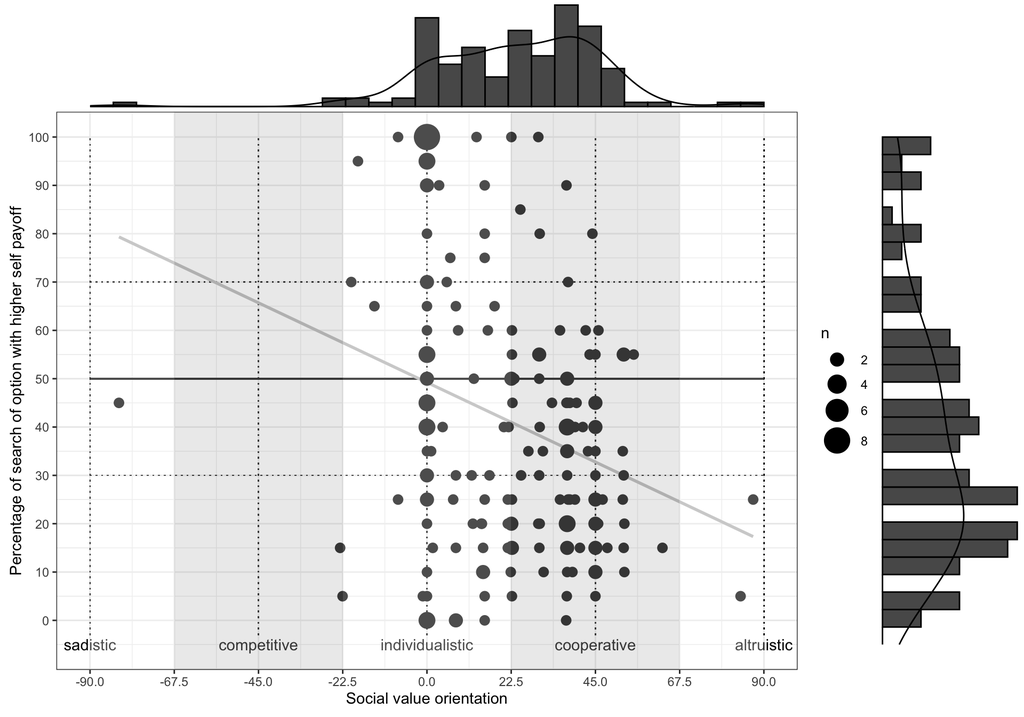

```r
ggMarginal(scatterP, type="densigram")
```

### Plot separated by assessment condition

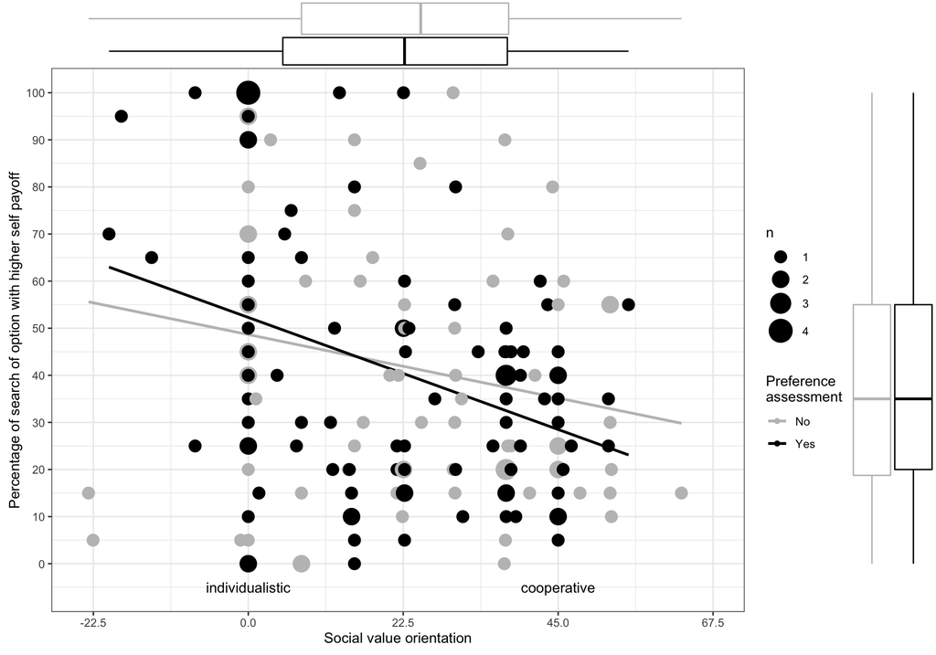

```r
ggMarginal(scatterP_g, type="boxplot", groupColour=T,size=8)
```

## Multilevel regression models

```r
indiv_search = c(indiv_search)

self_ratio =   SVO_tasks_2_single$S_2_1 / SVO_tasks_2_single$S_1_1
other_ratio =  SVO_tasks_2_single$O_1 / SVO_tasks_2_single$O_2
other_ratio[1] = NA

self_ratio = self_ratio[incl==1]
other_ratio = other_ratio[incl==1]

dats_analy = data.frame("id"=rep(1:n_part_s2,20),
                        "search"=indiv_search,
                        "SVO"=rep(SVO_part,20),
                        "Pref" = rep(cond,20),
                        "Own" = rep(self_ratio,each=n_part_s2),
                        "Other" = rep(other_ratio,each=n_part_s2)
)


dats_analy$Pref = as.factor(dats_analy$Pref)
levels(dats_analy$Pref) = c("without","with")
contrasts(dats_analy$Pref) = contr.sum(2)
contrasts(dats_analy$Pref) = contrasts(dats_analy$Pref)[2:1]

dats_analy_gg = dats_analy

dats_analy$SVO = dats_analy$SVO - mean(dats_analy$SVO)
dats_analy$Own = dats_analy$Own - mean(dats_analy$Own,na.rm=T)
dats_analy$Other= dats_analy$Other - mean(dats_analy$Other,na.rm=T)


mod = list()

mod[1] = glmer(search ~ SVO  + (1|id),data=dats_analy,
               family = "binomial")
mod[2] = glmer(search ~ SVO * Pref + (1|id),data=dats_analy,
               family = "binomial")
mod_expl[2] = glmer(search ~  SVO*Own +Other*SVO+(1|id),data=dats_analy,
                    family = "binomial")
names_mod = c("Intercept","SVO", "Pref. assesm.", "SVO x Pref. assesm.")

htmlreg(mod, custom.coef.names=names_mod,digits=3)
```

Statistical models

|  | Model 1 | Model 2 |
| --- | --- | --- |
| Intercept | -0.427*** | -0.431*** |
|  | (0.113) | (0.113) |
| SVO | -0.020*** | -0.021*** |
|  | (0.005) | (0.005) |
| Pref. assesm. |  | -0.006 |
|  |  | (0.113) |
| SVO x Pref. assesm. |  | -0.007 |
|  |  | (0.005) |
| AIC | 4291.684 | 4293.800 |
| BIC | 4310.380 | 4324.961 |
| Log Likelihood | -2142.842 | -2141.900 |
| Num. obs. | 3760 | 3760 |
| Num. groups: id | 188 | 188 |
| Var: id (Intercept) | 2.077 | 2.052 |

p < 0.001; p < 0.01; p < 0.05

```r
texreg(mod, custom.coef.names=names_mod,digits=3)
```

```
##
## \begin{table}
## \begin{center}
## \begin{tabular}{l c c}
## \hline
##  & Model 1 & Model 2 \\
## \hline
## Intercept           & $-0.427^{***}$ & $-0.431^{***}$ \\
##                     & $(0.113)$      & $(0.113)$      \\
## SVO                 & $-0.020^{***}$ & $-0.021^{***}$ \\
##                     & $(0.005)$      & $(0.005)$      \\
## Pref. assesm.       &                & $-0.006$       \\
##                     &                & $(0.113)$      \\
## SVO x Pref. assesm. &                & $-0.007$       \\
##                     &                & $(0.005)$      \\
## \hline
## AIC                 & $4291.684$     & $4293.800$     \\
## BIC                 & $4310.380$     & $4324.961$     \\
## Log Likelihood      & $-2142.842$    & $-2141.900$    \\
## Num. obs.           & $3760$         & $3760$         \\
## Num. groups: id     & $188$          & $188$          \\
## Var: id (Intercept) & $2.077$        & $2.052$        \\
## \hline
## \multicolumn{3}{l}{\scriptsize{$^{***}p<0.001$; $^{**}p<0.01$; $^{*}p<0.05$}}
## \end{tabular}
## \caption{Statistical models}
## \label{table:coefficients}
## \end{center}
## \end{table}
```

### Prepare plot model predictions

```r
mod = glmer(search ~ SVO +
              (1|id),data=dats_analy_gg,
            family = "binomial")

pred = ggpredict(mod,terms=c("SVO"))
```

```
## Data were 'prettified'. Consider using `terms="SVO [all]"` to get smooth plots.
```

```r
pl_1 = ggplot(pred, aes(x, predicted)) +
  geom_line()+
  geom_ribbon(aes(ymin=conf.low, ymax=conf.high), alpha=0.15) +
  scale_y_continuous(limits=c(0,1),
                     breaks=c(0,.1,.2,.3,.4,.5,.6,.7,.8,.9,1))+
  scale_x_continuous(limits=c(-90,90),breaks=c(-90,-67.5,-45,-22.5,0,22.5,45,67.5,90)) +
  geom_segment(aes(x=-90,xend=90,y=.5,yend=.5), color = "grey")+
  geom_segment(aes(x=-90,xend=-90,y=.05,yend=1), color = "grey")+
  geom_segment(aes(x=-45,xend=-45,y=.05,yend=1), color = "grey")+
  geom_segment(aes(x=0,xend=0,y=.05,yend=1), color = "grey")+
  geom_segment(aes(x=45,xend=45,y=.05,yend=1), color = "grey")+
  geom_segment(aes(x=90,xend=90,y=.05,yend=1), color = "grey")+
  annotate(geom="text", x=-90, y=.01, label="sadistic",
           color="black")+
  annotate(geom="text", x=-45, y=.01, label="competitive",
           color="black")+
  annotate(geom="text", x=45, y=.01, label="cooperative",
           color="black")+
  annotate(geom="text", x=0, y=.01, label="individualistic",
           color="black")+
  annotate(geom="text", x=90, y=.01, label="altruistic",
           color="black")+
  ylab("Likelihood of search for option with higher own payoff") +
  xlab("Social value orientation")

##

levels(dats_analy_gg$Pref) = c("no","yes")

mean_svo = mean(dats_analy_gg$SVO)

dats_analy_gg$SVO = dats_analy_gg$SVO - mean_svo

mod = glmer(search ~ SVO*Pref +
              (1|id),data=dats_analy_gg,
            family = "binomial")

pred = ggpredict(mod,terms=c("SVO","Pref"))
```

```
## Data were 'prettified'. Consider using `terms="SVO [all]"` to get smooth plots.
```

```r
pred$x  = pred$x + mean_svo

pl_2 = ggplot(pred, aes(x, predicted)) +
  geom_line(aes(linetype=group))+ scale_y_continuous(limits=c(0,1),
                                                     breaks=c(0,.1,.2,.3,.4,.5,.6,.7,.8,.9,1))+
  scale_x_continuous(limits=c(-90,90),breaks=c(-90,-67.5,-45,-22.5,0,22.5,45,67.5,90)) +
  geom_segment(aes(x=-90,xend=90,y=.5,yend=.5), color = "grey")+
  geom_segment(aes(x=-90,xend=-90,y=.05,yend=1), color = "grey")+
  geom_segment(aes(x=-45,xend=-45,y=.05,yend=1), color = "grey")+
  geom_segment(aes(x=0,xend=0,y=.05,yend=1), color = "grey")+
  geom_segment(aes(x=45,xend=45,y=.05,yend=1), color = "grey")+
  geom_segment(aes(x=90,xend=90,y=.05,yend=1), color = "grey")+
  annotate(geom="text", x=-90, y=.01, label="sadistic",
           color="black")+
  annotate(geom="text", x=-45, y=.01, label="competitive",
           color="black")+
  annotate(geom="text", x=45, y=.01, label="cooperative",
           color="black")+
  annotate(geom="text", x=0, y=.01, label="individualistic",
           color="black")+
  annotate(geom="text", x=90, y=.01, label="altruistic",
           color="black") +
  guides(linetype=guide_legend("Preference assessment"))+
  ylab("Likelihood of search for option with higher own payoff") +
  xlab("Social value orientation")+
  theme(legend.position="bottom")

##

mean_self = mean(dats_analy_gg$Own)
sd_self = sd(dats_analy_gg$Own)
dats_analy_gg$Own = dats_analy_gg$Own - mean_self

mean_other = mean(dats_analy_gg$Other,na.rm=T)
sd_other = sd(dats_analy_gg$Other,na.rm=T)
dats_analy_gg$Other = dats_analy_gg$Other - mean_other

mod = glmer(search ~    SVO*Own + SVO*Other +
              (1|id),data=dats_analy_gg,
            family = "binomial")

pred = ggpredict(mod,terms=c("SVO","Own"))
```

```
## Data were 'prettified'. Consider using `terms="SVO [all]"` to get smooth plots.
```

```r
pred$x = pred$x + mean_svo

levels(pred$group) = c(round(mean_self-sd_self,2),round(mean_self,2),round(mean_self+sd_self,2))

pl_3 = ggplot(pred, aes(x, predicted)) +
  geom_line(aes(linetype=group)) +
  scale_y_continuous(limits=c(0,1),
                     breaks=c(0,.1,.2,.3,.4,.5,.6,.7,.8,.9,1))+
  scale_x_continuous(limits=c(-90,90),breaks=c(-90,-67.5,-45,-22.5,0,22.5,45,67.5,90)) +
  geom_segment(aes(x=-90,xend=90,y=.5,yend=.5), color = "grey")+
  geom_segment(aes(x=-90,xend=-90,y=.05,yend=1), color = "grey")+
  geom_segment(aes(x=-45,xend=-45,y=.05,yend=1), color = "grey")+
  geom_segment(aes(x=0,xend=0,y=.05,yend=1), color = "grey")+
  geom_segment(aes(x=45,xend=45,y=.05,yend=1), color = "grey")+
  geom_segment(aes(x=90,xend=90,y=.05,yend=1), color = "grey")+
  annotate(geom="text", x=-90, y=.01, label="sadistic",
           color="black")+
  annotate(geom="text", x=-45, y=.01, label="competitive",
           color="black")+
  annotate(geom="text", x=45, y=.01, label="cooperative",
           color="black")+
  annotate(geom="text", x=0, y=.01, label="individualistic",
           color="black")+
  annotate(geom="text", x=90, y=.01, label="altruistic",
           color="black") +
  guides(linetype=guide_legend("Ratio own payoff")) +
  ylab("Likelihood of search for option with higher own payoff") +
  xlab("Social value orientation")+ theme(legend.position="bottom")

##

pred = ggpredict(mod,terms=c("SVO","Other"))
```

```
## Data were 'prettified'. Consider using `terms="SVO [all]"` to get smooth plots.
```

```r
pred$x = pred$x + mean_svo
levels(pred$group) = c(round(mean_other-sd_other,2),round(mean_other,2),round(mean_other+sd_other,2))


pl_4 = ggplot(pred, aes(x, predicted)) +
  geom_line(aes(linetype=group)) +
  scale_y_continuous(limits=c(0,1),
                     breaks=c(0,.1,.2,.3,.4,.5,.6,.7,.8,.9,1))+
  scale_x_continuous(limits=c(-90,90),breaks=c(-90,-67.5,-45,-22.5,0,22.5,45,67.5,90)) +
  geom_segment(aes(x=-90,xend=90,y=.5,yend=.5), color = "grey")+
  geom_segment(aes(x=-90,xend=-90,y=.05,yend=1), color = "grey")+
  geom_segment(aes(x=-45,xend=-45,y=.05,yend=1), color = "grey")+
  geom_segment(aes(x=0,xend=0,y=.05,yend=1), color = "grey")+
  geom_segment(aes(x=45,xend=45,y=.05,yend=1), color = "grey")+
  geom_segment(aes(x=90,xend=90,y=.05,yend=1), color = "grey")+
  annotate(geom="text", x=-90, y=.01, label="sadistic",
           color="black")+
  annotate(geom="text", x=-45, y=.01, label="competitive",
           color="black")+
  annotate(geom="text", x=45, y=.01, label="cooperative",
           color="black")+
  annotate(geom="text", x=0, y=.01, label="individualistic",
           color="black")+
  annotate(geom="text", x=90, y=.01, label="altruistic",
           color="black") +
  guides(linetype=guide_legend("Ratio other's payoff")) +
  ylab("Likelihood of search for option with higher own payoff") +
  xlab("Social value orientation")+ theme(legend.position="bottom")+
  theme(legend.position="bottom")

##

pred_val = seq(1-mean_self,3-mean_self,.1)
pred_string = paste("Own [",paste(pred_val,collapse=","),"]",collapse="")

pred_1 = ggpredict(mod,terms=pred_string)

pred_1$x = pred_1$x + mean_self

pred_val = seq(1-mean_other,3-mean_other,.1)
pred_string = paste("Other [",paste(pred_val,collapse=","),"]",collapse="")

pred_2 = ggpredict(mod,terms=pred_string)
pred_2$x = pred_2$x + mean_other

pl_data = data.frame(c(pred_1$x,pred_2$x),c(pred_1$predicted,pred_2$predicted),
                     as.factor(c(rep("Own",length(pred_1$x)),rep("Other",length(pred_2$x))))
)

names(pl_data) = c("x","predicted","group")

pl_5 = ggplot(pl_data, aes(x, predicted)) +
  geom_line(aes(linetype=group)) +
  scale_y_continuous(limits=c(0,1),
                     breaks=c(0,.1,.2,.3,.4,.5,.6,.7,.8,.9,1))+
  scale_x_continuous(limits=c(1,3.1))+
  geom_segment(aes(x=1,xend=3,y=.5,yend=.5), color = "grey")+
  guides(linetype=guide_legend("Type of payoff")) +
  ylab("Likelihood of search for option with higher own payoff") +
  xlab("Ratio payoff") + theme(legend.position="bottom") +
  scale_linetype(labels = c("Other's", "Own"))
```

## Choice in session 2

```r
choice_s_2 = choice[,-c(12,13,19,20)]

round(table(c(choice_s_2),c(search)) / sum(table(c(choice_s_2),c(search)) ) * 100)
```

```
##
##      1  2
##   1 34 13
##   2 25 28
```

## Reaction time

```r
rt = dats_s2_2  %>% select(
  contains("Time_search_Page Submit")
    )

order_items = dats_s2_2 %>% select(contains("Trial_"))

rt = rt[,-c(12,13,19,20)]

order_items = order_items[,-c(12,13,19,20)]
dats_analy = data.frame(dats_analy,"rt"=unlist(rt),"order" = unlist(order_items))


mod_rt = lmer(rt ~ SVO* Own * Other + (1|id)+(1|order),data=dats_analy)
```

```r
htmlreg(mod_rt,digits=3)
```

Statistical models

|  | Model 1 |
| --- | --- |
| (Intercept) | 6.105*** |
|  | (0.357) |
| SVO | 0.025* |
|  | (0.012) |
| Own | -0.008 |
|  | (0.349) |
| Other | -0.369 |
|  | (0.341) |
| SVO:Own | -0.021 |
|  | (0.016) |
| SVO:Other | -0.002 |
|  | (0.016) |
| Own:Other | 0.230 |
|  | (1.610) |
| SVO:Own:Other | -0.006 |
|  | (0.075) |
| AIC | 25150.094 |
| BIC | 25218.084 |
| Log Likelihood | -12564.047 |
| Num. obs. | 3572 |
| Num. groups: id | 188 |
| Num. groups: order | 24 |
| Var: id (Intercept) | 9.695 |
| Var: order (Intercept) | 1.402 |
| Var: Residual | 60.936 |

p < 0.001; p < 0.01; p < 0.05

# Plot target effects from both studies

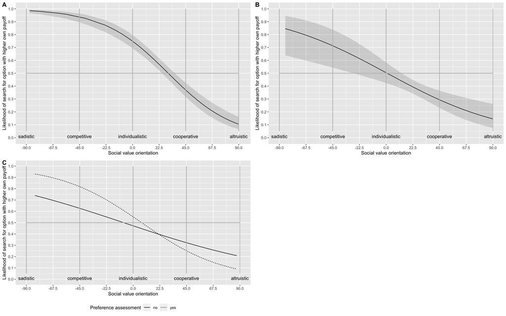

```r
figure <- ggarrange(pl_1_s_1,pl_1, pl_2,
                    labels = c("A", "B","C"),
                    ncol = 2, nrow = 2)
figure
```

```r
pdf("studies_1_2_model.pdf",pagecentre=T, width=14,height=11 ,paper = "special")

figure

dev.off()
```

# Appendix A: Items

```r
tasks_svo_table_1 =  cbind(1:24,tasks_svo)
tasks_svo_table_2 = numeric()

for(loop in 1:24){

  conc = tasks[loop,]
  open = tasks_compl[loop,]
  open = open[is.na(conc) == T]

  conc = conc[is.na(conc) == F]
  conc = as.character(conc)
  open = paste("(",open,")",sep="")


  tasks_svo_table_2 =
    rbind(tasks_svo_table_2,
          c(conc[1],open[1],conc[2:3],open[2],conc[4]))

}

tasks_svo_table_3 = matrix(as.character(unlist(tasks_svo_table_3)),
                           ncol=ncol(tasks_svo_table_3))

tasks_svo_table_3[,2] = paste("(",tasks_svo_table_3[,2],")",sep="")
tasks_svo_table_3[,5] = paste("(",tasks_svo_table_3[,5],")",sep="")


tasks_svo_table = cbind(rbind(tasks_svo_table_1[incl==1,],tasks_svo_table_1[incl==0,]),
                        rbind(tasks_svo_table_2[incl==1,],tasks_svo_table_2[incl==0,]),
                        table_perc_search_s1,
                        rbind(tasks_svo_table_3[incl==1,],tasks_svo_table_3[incl==0,]),
                        table_perc_search_s2) ##***

tasks_svo_table[,1] = 1:24

cor.test(table_perc_search_s1[1:20],table_perc_search_s2[1:20])
```

```
##
##  Pearson's product-moment correlation
##
## data:  table_perc_search_s1[1:20] and table_perc_search_s2[1:20]
## t = 4.7748, df = 18, p-value = 0.0001515
## alternative hypothesis: true correlation is not equal to 0
## 95 percent confidence interval:
##  0.4557873 0.8942406
## sample estimates:
##      cor
## 0.747534
```

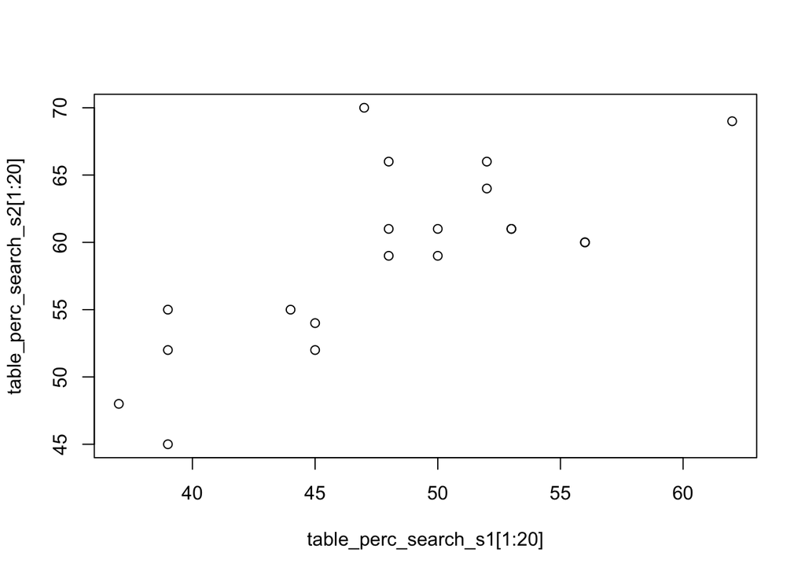

```r
plot(table_perc_search_s1[1:20],table_perc_search_s2[1:20])
```

```r
rownames(tasks_svo_table) <- NULL

kbl(tasks_svo_table,
    format = "latex",
    booktabs = TRUE,
    col.names = c("Item","Own", "Other's", "Own", "Other's", "Own 1", "Own 2","Other's", "Own 1", "Own 2", "Other's","","Own 1", "Own 2","Other's", "Own 1", "Own 2", "Other's",""),
    align = c("l", "c", "c", "c","c","c", "c","c", "c","c","c","c","c", "c", "c","c","c","c","c"),
    caption="."


) %>%
  add_header_above(c(" ", "Payoff Option 1" = 2, "Payoff Option 2" = 2,"Payoff Option 1" = 3, "Payoff Option 2" = 3,"% Opt 1" = 1,"Payoff Option 1" = 3, "Payoff Option 2" = 3,"% Opt 1" = 1)) %>%
  add_header_above(c(" ", "SVO Ring Measure" = 4,"ASE Study 1"=7,"ASE Study 2"=7))
```

```r
kbl(tasks_svo_table,
    format = "html",

    col.names = c("Item","Own", "Other's", "Own", "Other's", "Own 1", "Own 2","Other's", "Own 1", "Own 2", "Other's","","Own 1", "Own 2","Other's", "Own 1", "Own 2", "Other's",""),
    align = c("l", "c", "c", "c","c","c", "c","c", "c","c","c","c","c", "c", "c","c","c","c","c"),
    caption="."


) %>%
  add_header_above(c(" ", "Payoff Option 1" = 2, "Payoff Option 2" = 2,"Payoff Option 1" = 3, "Payoff Option 2" = 3,"% Opt 1" = 1,"Payoff Option 1" = 3, "Payoff Option 2" = 3,"% Opt 1" = 1)) %>%
  add_header_above(c(" ", "SVO Ring Measure" = 4,"ASE Study 1"=7,"ASE Study 2"=7))
```

.

SVO Ring Measure

ASE Study 1

ASE Study 2

Payoff Option 1

Payoff Option 2

Payoff Option 1

Payoff Option 2

% Opt 1

Payoff Option 1

Payoff Option 2

% Opt 1

Item

Own

Other’s

Own

Other’s

Own 1

Own 2

Other’s

Own 1

Own 2

Other’s

Own 1

Own 2

Other’s

Own 1

Own 2

Other’s

1

1.5

2.6

2.1

2.1

1.16

(1.74)

0.8

1.5

(1.5)

0

62

1.16

(1.74)

0.8

1.5

(1.5)

0

69

2

0

-3

-0.8

-2.9

1.94

(1.3)

1.14

2.33

(1.01)

0.34

52

1.94

(1.3)

1.14

2.33

(1.01)

0.34

64

3

3

0

2.9

-0.8

1.53

(2.74)

2.17

2.14

(2.23)

1.37

50

1.53

(2.74)

2.17

2.14

(2.23)

1.37

59

4

-2.9

0.8

-2.6

1.5

0.16

(5.19)

3.25

0.38

(5.07)

2.45

50

0.08

(2.6)

1.63

0.19

(2.54)

1.23

61

5

-2.6

-1.5

-2.9

-0.8

4.44

(1.48)

4.06

5.58

(0.54)

3.26

45

2.22

(0.74)

2.03

2.79

(0.27)

1.63

54

6

-0.8

2.9

0

3

2.74

(4.49)

5.13

3

4.33

48

1.37

(2.25)

2.57

1.5

(2.17)

2.17

59

7

0

3

0.8

2.9

7.29

(0.34)

5.93

7.61

(0.16)

5.13

56

3.65

(0.17)

2.97

3.81

(0.08)

2.57

60

8

-0.8

-2.9

-1.5

-2.6

9.01

(0.27)

7.28

9.2

(0.28)

6.48

56

4.51

(0.14)

3.64

4.6

(0.14)

3.24

60

9

0.8

-2.9

0

-3

0.18

(2.42)

1.5

0.33

(2.57)

0.8

52

0.18

(2.42)

1.5

0.33

(2.57)

0.8

66

10

2.1

-2.1

1.5

-2.6

0.91

(2.03)

1.84

1.03

(2.21)

1.14

47

0.91

(2.03)

1.84

1.03

(2.21)

1.14

70

11

2.9

-0.8

2.6

-1.5

2.35

(1.62)

2.87

4.23

(0.04)

2.17

39

2.35

(1.62)

2.87

4.23

(0.04)

2.17

52

12

-1.5

-2.6

-2.1

-2.1

6.59

(0.54)

5.83

7.09

(0.16)

5.13

48

3.3

(0.27)

2.92

3.55

(0.08)

2.57

61

13

-2.1

2.1

-1.5

2.6

7.12

(0.61)

6.63

7.68

(0.4)

5.93

53

3.56

(0.31)

3.32

3.84

(0.2)

2.97

61

14

0.8

2.9

1.5

2.6

8.27

(0.81)

7.98

8.76

(0.62)

7.28

53

2.07

(0.2)

2

2.19

(0.16)

1.82

61

15

2.6

-1.5

2.1

-2.1

0.86

(1.34)

2.26

1.04

(1.33)

1.19

48

0.86

(1.34)

2.26

1.04

(1.33)

1.19

66

16

-1.5

2.6

-0.8

2.9

1.3

(1.32)

2.44

2.8

(0.14)

1.84

44

1.3

(1.32)

2.44

2.8

(0.14)

1.84

55

17

2.6

1.5

2.9

0.8

3.51

(2.19)

5.36

5.75

(0.11)

4.76

37

3.51

(2.19)

5.36

5.75

(0.11)

4.76

48

18

-2.6

1.5

-2.1

2.1

5.1

(1.93)

6.43

6.52

(0.41)

5.83

39

2.55

(0.97)

3.22

3.26

(0.21)

2.92

55

19

2.1

2.1

2.6

1.5

4.6

(2.55)

7.23

6.81

(0.44)

6.63

39

2.3

(1.28)

3.62

3.41

(0.22)

3.32

45

20

-2.9

-0.8

-3

0

7.79

(1.49)

8.57

8.79

(0.56)

7.98

45

3.9

(0.75)

4.29

4.4

(0.28)

3.99

52

21

-2.1

-2.1

-2.6

-1.5

1.19

(3.89)

3.99

0.99

(3.88)

3.25

78

1.19

(3.89)

3.99

0.99

(3.88)

3.25

57

22

2.9

0.8

3

0

2.23

(2.96)

4.76

1.35

(3.51)

3.6

73

2.23

(2.96)

4.76

1.35

(3.51)

3.6

61

23

1.5

-2.6

0.8

-2.9

3.4

(0.41)

3.47

3.26

(0.71)

2.87

75

3.4

(0.41)

3.47

3.26

(0.71)

2.87

63

24

-3

0

-2.9

0.8

1.86

(4.69)

4.3

1.25

(5.44)

3.4

73

0.93

(2.35)

2.15

0.63

(2.72)

1.7

57

# Appendix B: Properties of items

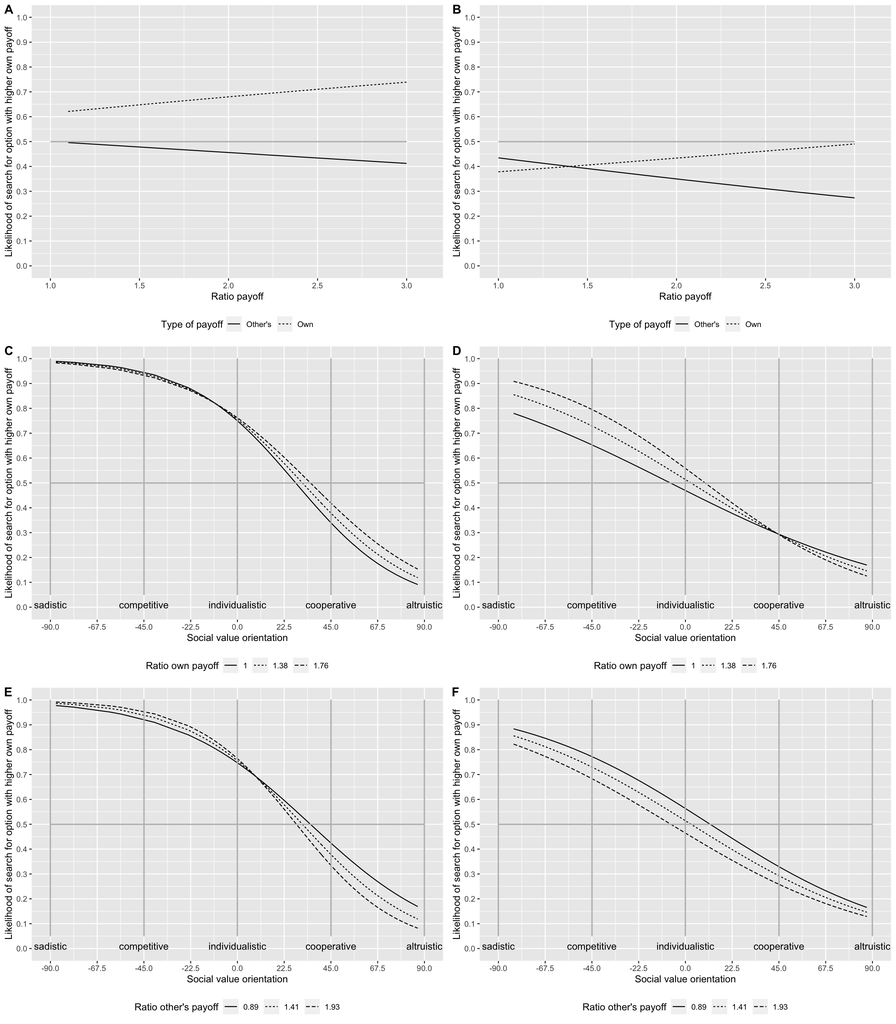

```r
figure <- ggarrange(pl_main_s1,pl_5,pl_self_s1,pl_3,pl_other_s1, pl_4,
                    labels = c("A", "B","C","D","E","F"),
                    ncol = 2, nrow = 3)
figure
```

```r
pdf("studies_1_2_ratios_model.pdf",pagecentre=T, width=14,height=16 ,paper = "special")

figure

dev.off()
```

```r
names_mod = c("Intercept","SVO","R[own]: Ratio own payoffs","R[other's]: Ratio other's payoffs",
              "SVO x R[own]", "SVO x R[other's]")

htmlreg(mod_expl, custom.coef.names=names_mod,
        custom.model.names = c("Study 1", "Study 2"),digits=3,
        include.loglik = F,
        include.aic=F,
        include.bic=F
)
```

Statistical models

|  | Study 1 | Study 2 |
| --- | --- | --- |
| Intercept | 0.179 | -0.410*** |
|  | (0.097) | (0.115) |
| SVO | -0.036*** | -0.021*** |
|  | (0.004) | (0.005) |
| R[own]: Ratio own payoffs | 0.287*** | 0.229* |
|  | (0.082) | (0.103) |
| R[other’s]: Ratio other’s payoffs | -0.178** | -0.356*** |
|  | (0.064) | (0.081) |
| SVO x R[own] | 0.008* | -0.011* |
|  | (0.003) | (0.005) |
| SVO x R[other’s] | -0.010*** | 0.001 |
|  | (0.003) | (0.004) |
| Num. obs. | 5814 | 3572 |
| Num. groups: id | 306 | 188 |
| Var: id (Intercept) | 2.459 | 2.120 |

p < 0.001; p < 0.01; p < 0.05

```r
texreg(mod_expl, custom.coef.names=names_mod,
       custom.model.names = c("Study 1", "Study 2"),digits=3,
       include.loglik = F,
       include.aic=F,
       include.bic=F
)
```

```
##
## \begin{table}
## \begin{center}
## \begin{tabular}{l c c}
## \hline
##  & Study 1 & Study 2 \\
## \hline
## Intercept                         & $0.179$        & $-0.410^{***}$ \\
##                                   & $(0.097)$      & $(0.115)$      \\
## SVO                               & $-0.036^{***}$ & $-0.021^{***}$ \\
##                                   & $(0.004)$      & $(0.005)$      \\
## R[own]: Ratio own payoffs         & $0.287^{***}$  & $0.229^{*}$    \\
##                                   & $(0.082)$      & $(0.103)$      \\
## R[other's]: Ratio other's payoffs & $-0.178^{**}$  & $-0.356^{***}$ \\
##                                   & $(0.064)$      & $(0.081)$      \\
## SVO x R[own]                      & $0.008^{*}$    & $-0.011^{*}$   \\
##                                   & $(0.003)$      & $(0.005)$      \\
## SVO x R[other's]                  & $-0.010^{***}$ & $0.001$        \\
##                                   & $(0.003)$      & $(0.004)$      \\
## \hline
## Num. obs.                         & $5814$         & $3572$         \\
## Num. groups: id                   & $306$          & $188$          \\
## Var: id (Intercept)               & $2.459$        & $2.120$        \\
## \hline
## \multicolumn{3}{l}{\scriptsize{$^{***}p<0.001$; $^{**}p<0.01$; $^{*}p<0.05$}}
## \end{tabular}
## \caption{Statistical models}
## \label{table:coefficients}
## \end{center}
## \end{table}
```